# PCA Prractice

Shan Wang

09 April, 2020

In this lab, we perform PCA on the USArrests data set, which is part of the base R package.

# 1 Loading and Examining the Data

```r
data('USArrests')
states=row.names(USArrests)
```

The rows of the data set contain the 50 states, in alphabetical order

```r
names(USArrests)
```

```
## [1] "Murder"   "Assault"  "UrbanPop" "Rape"
```

The columns of the data set contain the four variable.

We first briefly examine the data. We notice that the variables have vastly different means.

```r
apply(USArrests , 2, mean)
```

```
##   Murder  Assault UrbanPop     Rape
##      7.8    170.8     65.5     21.2
```

The apply() function allows us to apply a function—in this case, the mean() function—to each row or column of the data set

The second input here denotes whether we wish to compute the mean of the rows, 1, or the columns, 2

There are on average three times as many rapes as murders, and more than eight times as many assaults as rapes

We can also examine the variances of the four variables using the apply() function

```r
apply(USArrests, 2, var)
```

```
##   Murder  Assault UrbanPop     Rape
##       19     6945      210       88
```

Not surprisingly, the variables also have vastly different variances: the UrbanPop variable measures the percentage of the population in each state living in an urban area, which is not a comparable number to the number of rapes in each state per 100,000 individuals.

If we failed to scale the variables before performing PCA, then most of the principal components that we observed would be driven by the Assault variable, since it has by far the largest mean and variance.

Thus, it is important to standardize the variables to have mean zero and standard deviation one before performing PCA.

# 2 Principal Components Analysis

We now perform principal components analysis using the prcomp() function, which is one of several functions in R that perform PCA.

```r
pr.out =prcomp(USArrests, scale =TRUE)
```

By default, the prcomp() function centers the variables to have mean zero scale=TRUE: scale the variables to have standard deviation one The output from prcomp() contains a number of useful quantities

```r
names(pr.out )
```

```
## [1] "sdev"     "rotation" "center"   "scale"    "x"
```

The center and scale components correspond to the means and standard deviations of the variables that were used for scaling prior to implementing PCA

```r
pr.out$center
```

```
##   Murder  Assault UrbanPop     Rape
##      7.8    170.8     65.5     21.2
```

```r
pr.out$scale
```

```
##   Murder  Assault UrbanPop     Rape
##      4.4     83.3     14.5      9.4
```

The rotation matrix provides the principal component loadings

```r
pr.out$rotation
```

```
##            PC1   PC2   PC3    PC4
## Murder   -0.54  0.42 -0.34  0.649
## Assault  -0.58  0.19 -0.27 -0.743
## UrbanPop -0.28 -0.87 -0.38  0.134
## Rape     -0.54 -0.17  0.82  0.089
```

each column of pr.out$rotation contains the corresponding principal component loading vector

We see that there are four distinct principal components

This is to be expected because there are in general min(n − 1, p) informative principal components in a data set with n observations and p variables

Using the prcomp() function, we do not need to explicitly multiply the data by the principal component loading vectors in order to obtain the principal component score vectors

Rather the 50×4 matrix x has as its columns the principal component score vectors. That is, the kth column is the kth principal component score vector.

```r
dim(pr.out$x)
```

```
## [1] 50  4
```

```r
pr.out$x
```

```
##                   PC1    PC2    PC3     PC4
## Alabama        -0.976  1.122 -0.440  0.1547
## Alaska         -1.931  1.062  2.020 -0.4342
## Arizona        -1.745 -0.738  0.054 -0.8263
## Arkansas        0.140  1.109  0.113 -0.1810
## California     -2.499 -1.527  0.593 -0.3386
## Colorado       -1.499 -0.978  1.084  0.0015
## Connecticut     1.345 -1.078 -0.637 -0.1173
## Delaware       -0.047 -0.322 -0.711 -0.8731
## Florida        -2.983  0.039 -0.571 -0.0953
## Georgia        -1.623  1.266 -0.339  1.0660
## Hawaii          0.903 -1.555  0.050  0.8937
## Idaho           1.623  0.209  0.257 -0.4941
## Illinois       -1.365 -0.675 -0.671 -0.1208
## Indiana         0.500 -0.150  0.226  0.4204
## Iowa            2.231 -0.103  0.163  0.0174
## Kansas          0.789 -0.267  0.025  0.2044
## Kentucky        0.743  0.949 -0.028  0.6638
## Louisiana      -1.549  0.862 -0.776  0.4502
## Maine           2.373  0.373 -0.065 -0.3271
## Maryland       -1.746  0.423 -0.156 -0.5535
## Massachusetts   0.481 -1.460 -0.603 -0.1778
## Michigan       -2.087 -0.154  0.381  0.1013
## Minnesota       1.676 -0.626  0.152  0.0666
## Mississippi    -0.986  2.370 -0.733  0.2133
## Missouri       -0.690 -0.261  0.374  0.2236
## Montana         1.174  0.531  0.244  0.1225
## Nebraska        1.253 -0.192  0.174  0.0157
## Nevada         -2.846 -0.768  1.152  0.3114
## New Hampshire   2.360 -0.018  0.036 -0.0328
## New Jersey     -0.180 -1.435 -0.757  0.2409
## New Mexico     -1.960  0.141  0.182 -0.3361
## New York       -1.666 -0.815 -0.637 -0.0133
## North Carolina -1.112  2.206 -0.855 -0.9448
## North Dakota    2.962  0.593  0.298 -0.2514
## Ohio            0.224 -0.735 -0.031  0.4692
## Oklahoma        0.309 -0.285 -0.015  0.0102
## Oregon         -0.059 -0.536  0.930 -0.2354
## Pennsylvania    0.879 -0.565 -0.397  0.3555
## Rhode Island    0.855 -1.477 -1.356 -0.6074
## South Carolina -1.307  1.914 -0.298 -0.1301
## South Dakota    1.968  0.815  0.385 -0.1085
## Tennessee      -0.990  0.852  0.186  0.6463
## Texas          -1.342 -0.408 -0.487  0.6367
## Utah            0.545 -1.457  0.291 -0.0815
## Vermont         2.773  1.388  0.833 -0.1434
## Virginia        0.095  0.198  0.012  0.2092
## Washington      0.215 -0.960  0.619 -0.2186
## West Virginia   2.087  1.411  0.104  0.1306
## Wisconsin       2.059 -0.605 -0.137  0.1823
## Wyoming         0.623  0.318 -0.238 -0.1650
```

We can plot the first two principal components as follows

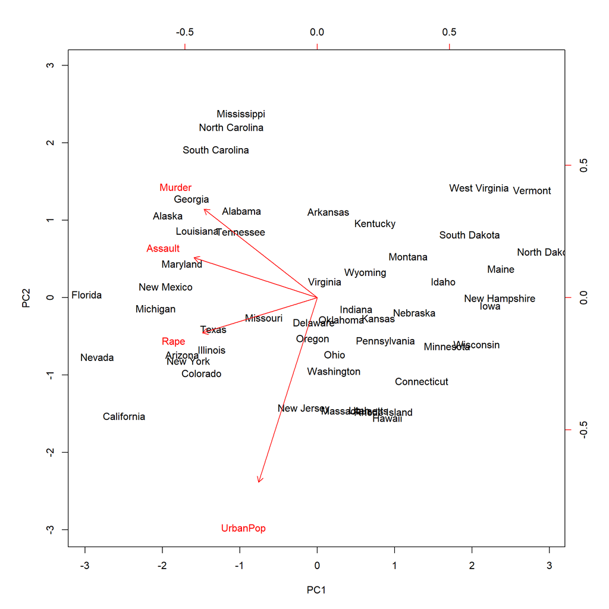

```r
biplot (pr.out, scale =0)
```

scale=0: ensure that the arrows are scaled to represent the loadings

other values for scale give slightly different biplots with different interpretations

Notice that this figure is a mirror image of the figure we use in class

Recall that the principal components are only unique up to a sign change, so we can reproduce the figure we use in class by making a few small changes

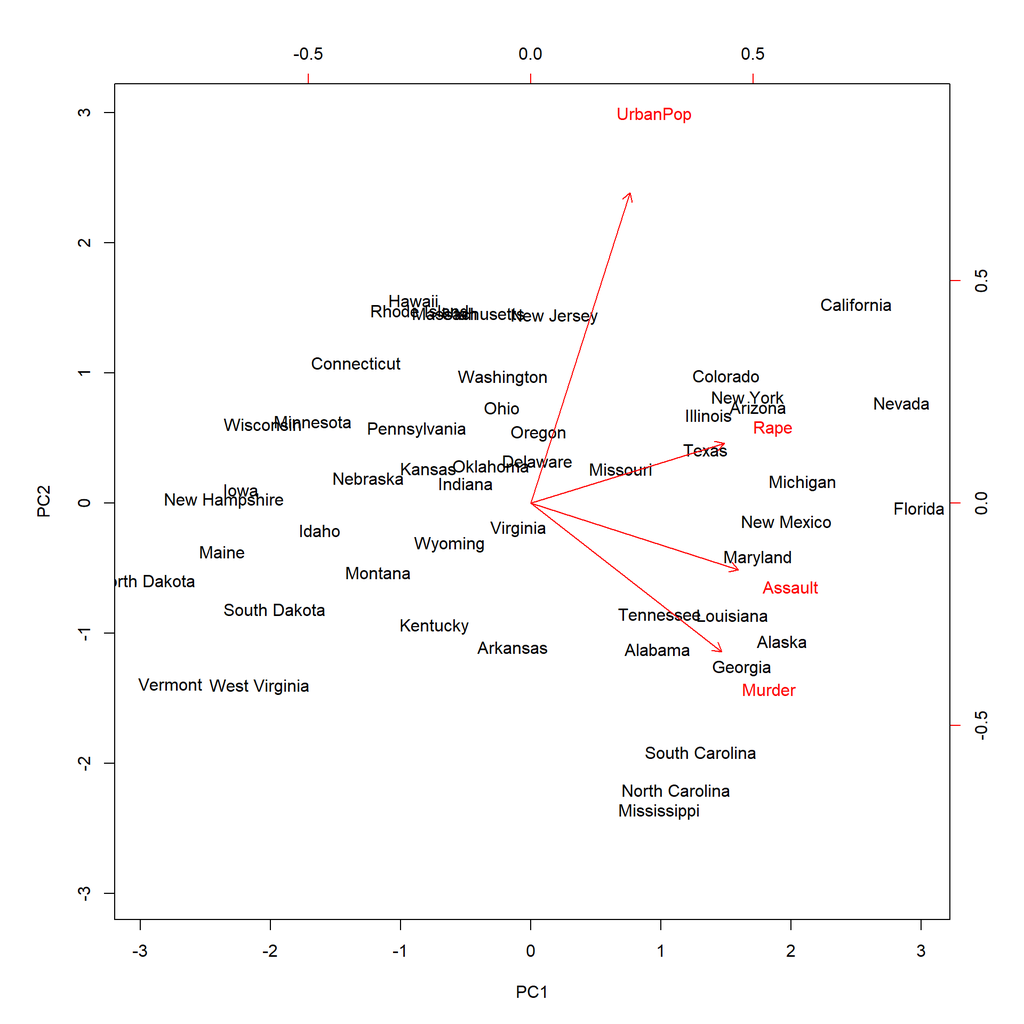

```r
pr.out$rotation=-pr.out$rotation
pr.out$x=-pr.out$x
biplot(pr.out , scale =0)
```

The prcomp() function also outputs the standard deviation of each principal component.

For instance, on the USArrests data set, we can access these standard deviations as follows

```r
pr.out$sdev
```

```
## [1] 1.57 0.99 0.60 0.42
```

The variance explained by each principal component is obtained by squaring these

```r
pr.var =pr.out$sdev^2
pr.var
```

```
## [1] 2.48 0.99 0.36 0.17
```

To compute the proportion of variance explained by each principal component, we simply divide the variance explained by each principal component by the total variance explained by all four principal components:

```r
pve=pr.var/sum(pr.var)
pve
```

```
## [1] 0.620 0.247 0.089 0.043
```

We see that the first principal component explains 62.0% of the variance in the data, the next principal component explains 24.7% of the variance, and so forth.

We can plot the PVE explained by each component, as well as the cumulative PVE, as follows:

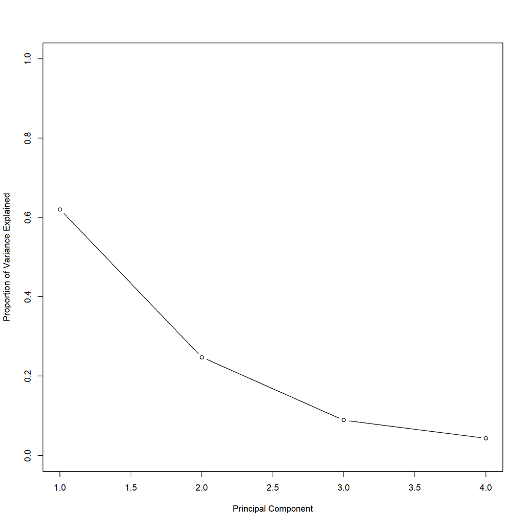

```r
plot(pve, xlab=" Principal Component ", ylab=" Proportion of Variance Explained ", ylim=c(0,1) ,type='b')
```

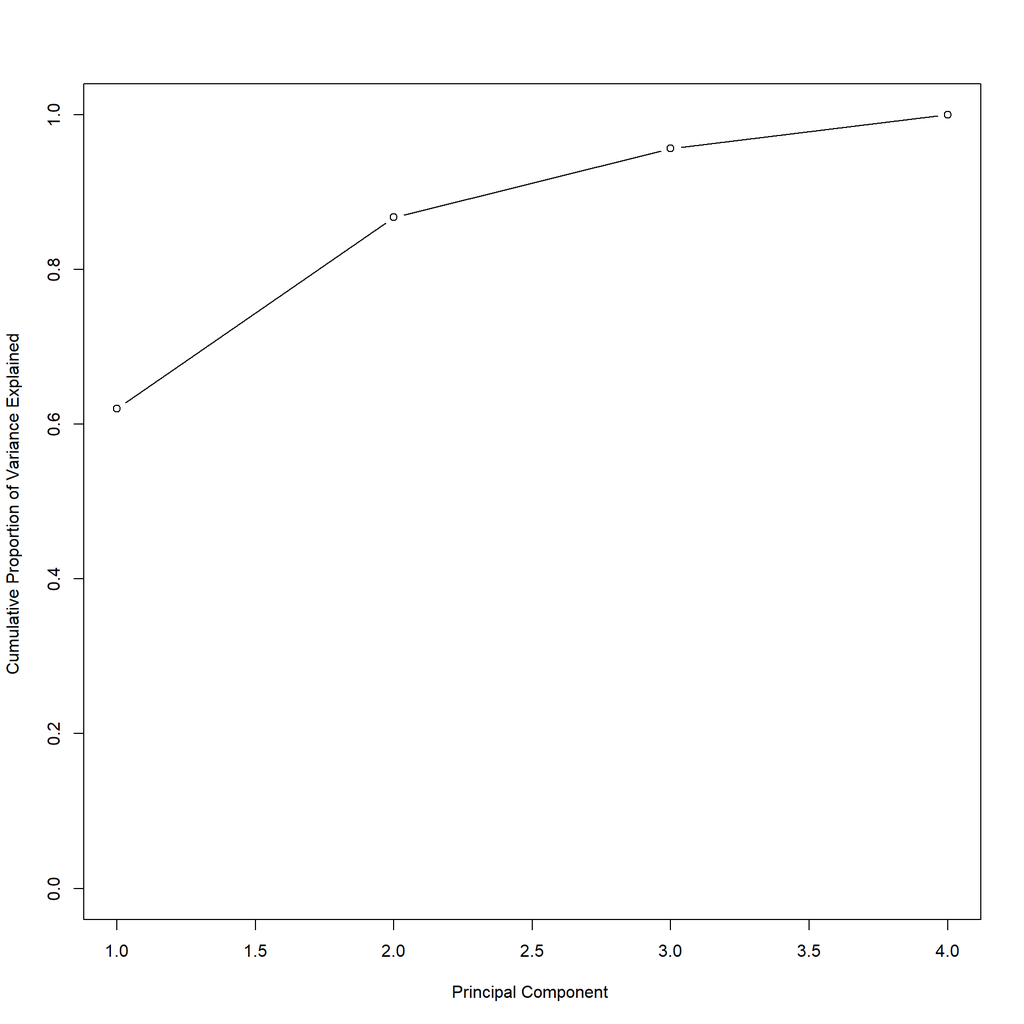

```r
plot(cumsum (pve ), xlab="Principal Component ", ylab ="Cumulative Proportion of Variance Explained ", ylim=c(0,1) , type='b')
```

The function cumsum() computes the cumulative sum of the elements of a numeric vector For instance:

```r
a=c(1,2,8,-3)
cumsum(a)
```

```
## [1]  1  3 11  8
```